# Dengue - Machine Learning

22-04-2024

## Objective

- To provide an overview of the initial findings from applying different machine learning methods and discuss their implications and possible next steps.

## Selected methods

- K-Nearest Neightbors (knn).
- Support Vector Machines (svm).
- Random Forest (rf).
- eXtreme Gradient Boosting (xgb).
- Least Absolute Shrinkage and Selection Operator (lasso).
- Bayesian Additive Regression Trees (bart).

## Workflow

[figure not shown]

## Cross-validation

> *“When purely (non-linear, nonparametric) autoregressive methods are applied to forecasting problems, as is often the case (e.g., when using Machine Learning methods), the aforementioned problems of CV are largely irrelevant, and CV can and should be used without modification, as in the independent case.”*

Christoph Bergmeir, Rob J. Hyndman, Bonsoo Koo. A note on the validity of cross-validation for evaluating autoregressive time series prediction. Computational Statistics & Data Analysis, Volume 120, 2018.

## Forecast Strategies

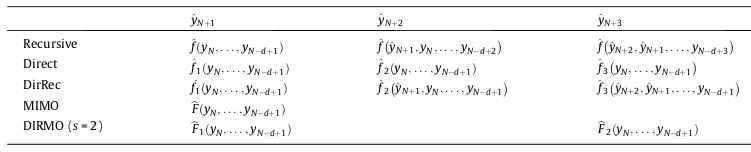

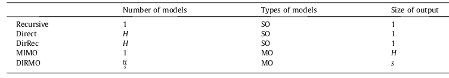

## Pros & Cons

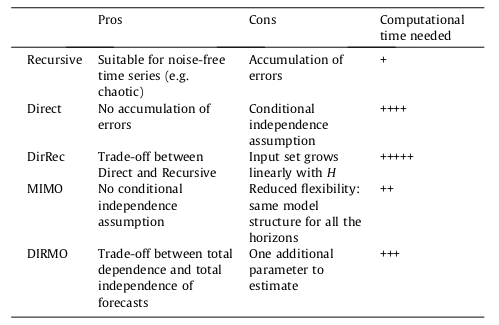

## Direct Strategy Results

## Train-Test

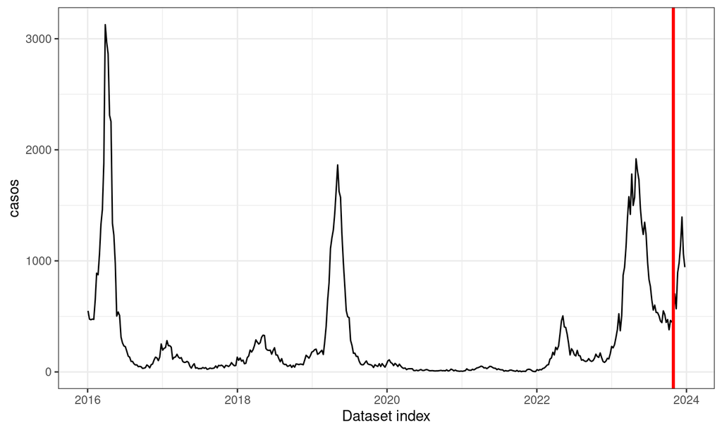

## Lagged Data Frame

|  | casos | casos_lag_1 | casos_lag_2 | casos_lag_3 | casos_lag_4 | casos_lag_5 | casos_lag_6 | casos_lag_7 | casos_lag_8 | tempmed_lag_1 | tempmed_lag_2 | tempmed_lag_3 | tempmed_lag_4 | tempmed_lag_5 | tempmed_lag_6 | tempmed_lag_7 | tempmed_lag_8 | umidmed_lag_1 | umidmed_lag_2 | umidmed_lag_3 | umidmed_lag_4 | umidmed_lag_5 | umidmed_lag_6 | umidmed_lag_7 | umidmed_lag_8 |
| --- | --- | --- | --- | --- | --- | --- | --- | --- | --- | --- | --- | --- | --- | --- | --- | --- | --- | --- | --- | --- | --- | --- | --- | --- | --- |
| 9 | 1064 | 875 | 889 | 646 | 473 | 476 | 470 | 476 | 550 | 25.79206314 | 25.59028929 | 27.47954614 | 28.78750971 | 25.97251986 | 22.14240343 | 25.31944471 | 24.70849971 | 81.83958371 | 84.07236129 | 70.73252214 | 68.20633643 | 81.842758 | 87.28571429 | 85.00865743 | 76.085932 |
| 10 | 1328 | 1064 | 875 | 889 | 646 | 473 | 476 | 470 | 476 | 25.086078 | 25.79206314 | 25.59028929 | 27.47954614 | 28.78750971 | 25.97251986 | 22.14240343 | 25.31944471 | 79.72820543 | 81.83958371 | 84.07236129 | 70.73252214 | 68.20633643 | 81.842758 | 87.28571429 | 85.00865743 |
| 11 | 1462 | 1328 | 1064 | 875 | 889 | 646 | 473 | 476 | 470 | 25.85431514 | 25.086078 | 25.79206314 | 25.59028929 | 27.47954614 | 28.78750971 | 25.97251986 | 22.14240343 | 83.05680714 | 79.72820543 | 81.83958371 | 84.07236129 | 70.73252214 | 68.20633643 | 81.842758 | 87.28571429 |
| 12 | 1877 | 1462 | 1328 | 1064 | 875 | 889 | 646 | 473 | 476 | 24.01956171 | 25.85431514 | 25.086078 | 25.79206314 | 25.59028929 | 27.47954614 | 28.78750971 | 25.97251986 | 87.84780771 | 83.05680714 | 79.72820543 | 81.83958371 | 84.07236129 | 70.73252214 | 68.20633643 | 81.842758 |
| 13 | 3127 | 1877 | 1462 | 1328 | 1064 | 875 | 889 | 646 | 473 | 24.80519457 | 24.01956171 | 25.85431514 | 25.086078 | 25.79206314 | 25.59028929 | 27.47954614 | 28.78750971 | 84.67159029 | 87.84780771 | 83.05680714 | 79.72820543 | 81.83958371 | 84.07236129 | 70.73252214 | 68.20633643 |
| 14 | 2968 | 3127 | 1877 | 1462 | 1328 | 1064 | 875 | 889 | 646 | 25.33346071 | 24.80519457 | 24.01956171 | 25.85431514 | 25.086078 | 25.79206314 | 25.59028929 | 27.47954614 | 86.73078686 | 84.67159029 | 87.84780771 | 83.05680714 | 79.72820543 | 81.83958371 | 84.07236129 | 70.73252214 |
| 15 | 2863 | 2968 | 3127 | 1877 | 1462 | 1328 | 1064 | 875 | 889 | 24.33621014 | 25.33346071 | 24.80519457 | 24.01956171 | 25.85431514 | 25.086078 | 25.79206314 | 25.59028929 | 84.37464857 | 86.73078686 | 84.67159029 | 87.84780771 | 83.05680714 | 79.72820543 | 81.83958371 | 84.07236129 |
| 16 | 2312 | 2863 | 2968 | 3127 | 1877 | 1462 | 1328 | 1064 | 875 | 27.04957757 | 24.33621014 | 25.33346071 | 24.80519457 | 24.01956171 | 25.85431514 | 25.086078 | 25.79206314 | 73.47632429 | 84.37464857 | 86.73078686 | 84.67159029 | 87.84780771 | 83.05680714 | 79.72820543 | 81.83958371 |
| 17 | 2254 | 2312 | 2863 | 2968 | 3127 | 1877 | 1462 | 1328 | 1064 | 26.01130957 | 27.04957757 | 24.33621014 | 25.33346071 | 24.80519457 | 24.01956171 | 25.85431514 | 25.086078 | 75.30208214 | 73.47632429 | 84.37464857 | 86.73078686 | 84.67159029 | 87.84780771 | 83.05680714 | 79.72820543 |
| 18 | 1339 | 2254 | 2312 | 2863 | 2968 | 3127 | 1877 | 1462 | 1328 | 22.42086029 | 26.01130957 | 27.04957757 | 24.33621014 | 25.33346071 | 24.80519457 | 24.01956171 | 25.85431514 | 78.90600629 | 75.30208214 | 73.47632429 | 84.37464857 | 86.73078686 | 84.67159029 | 87.84780771 | 83.05680714 |

[output cut: 391 more lines]

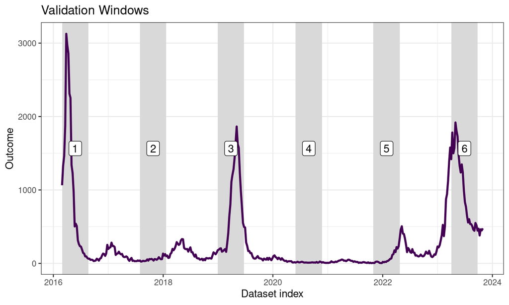

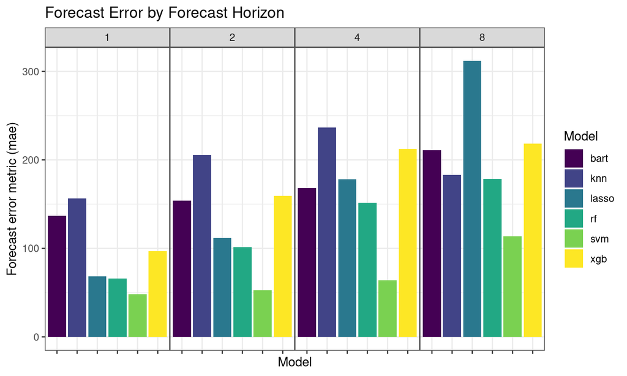

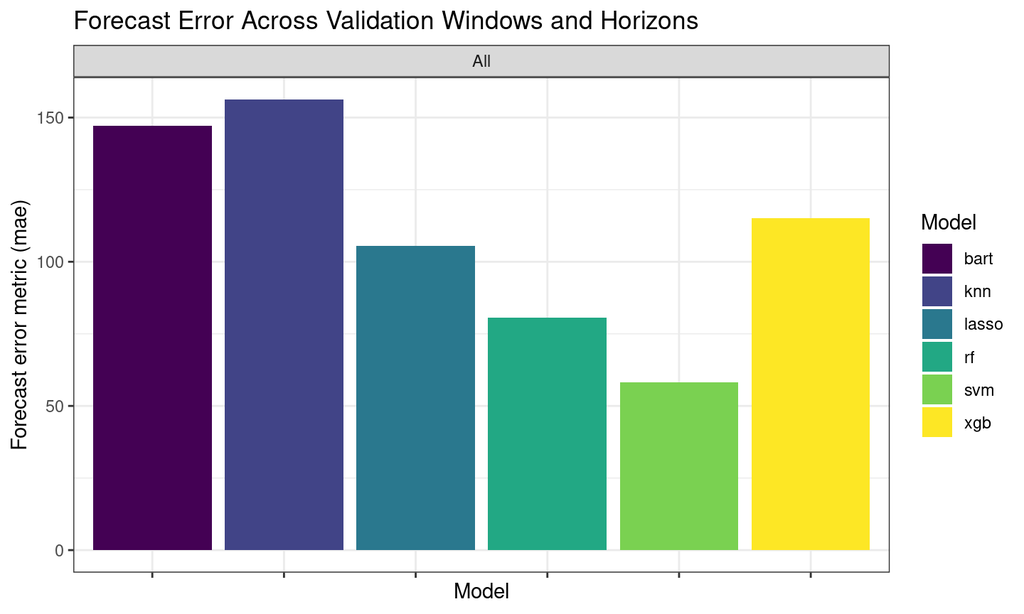

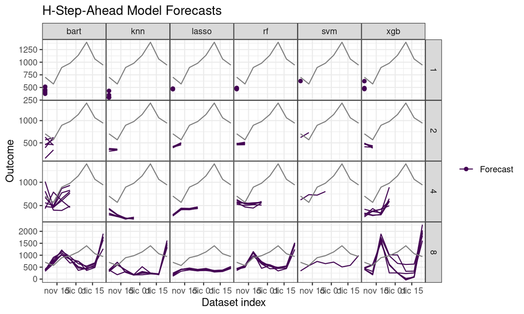

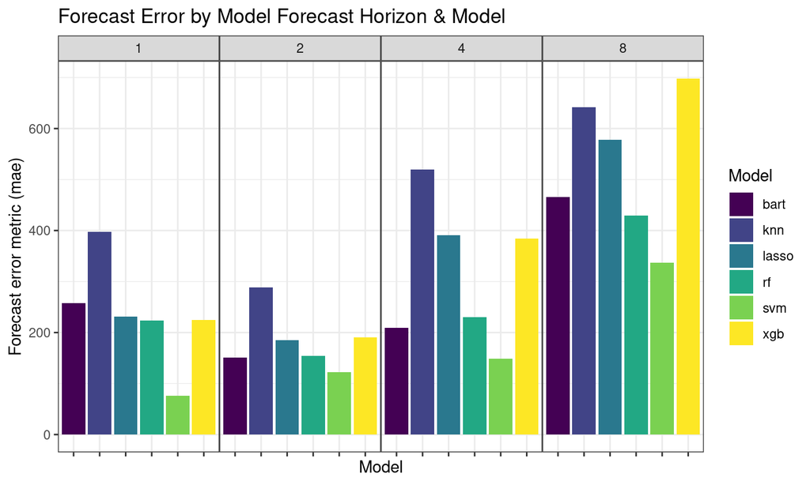

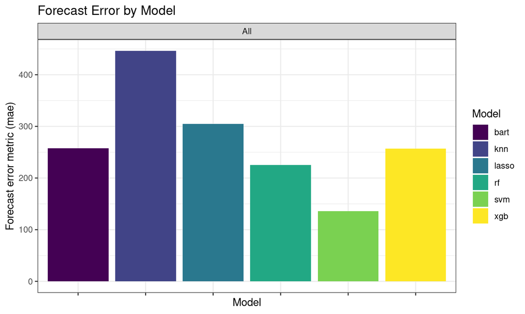

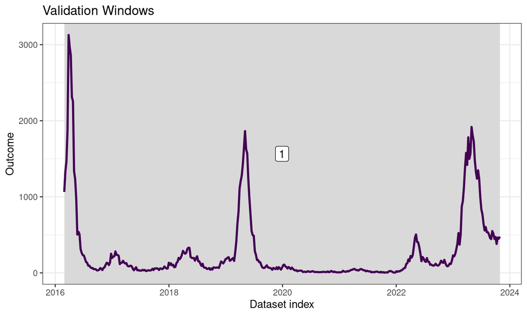

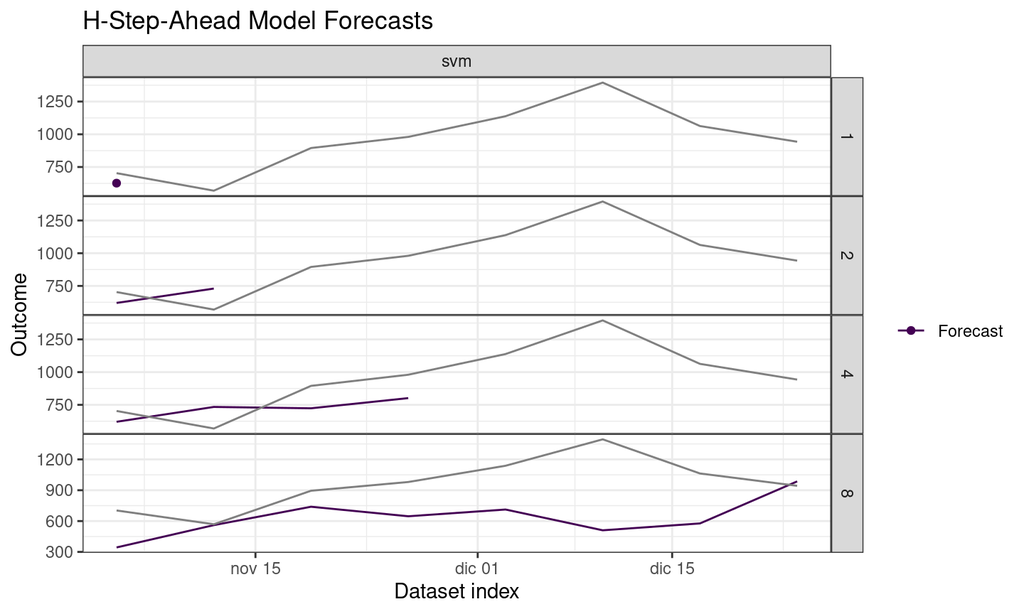

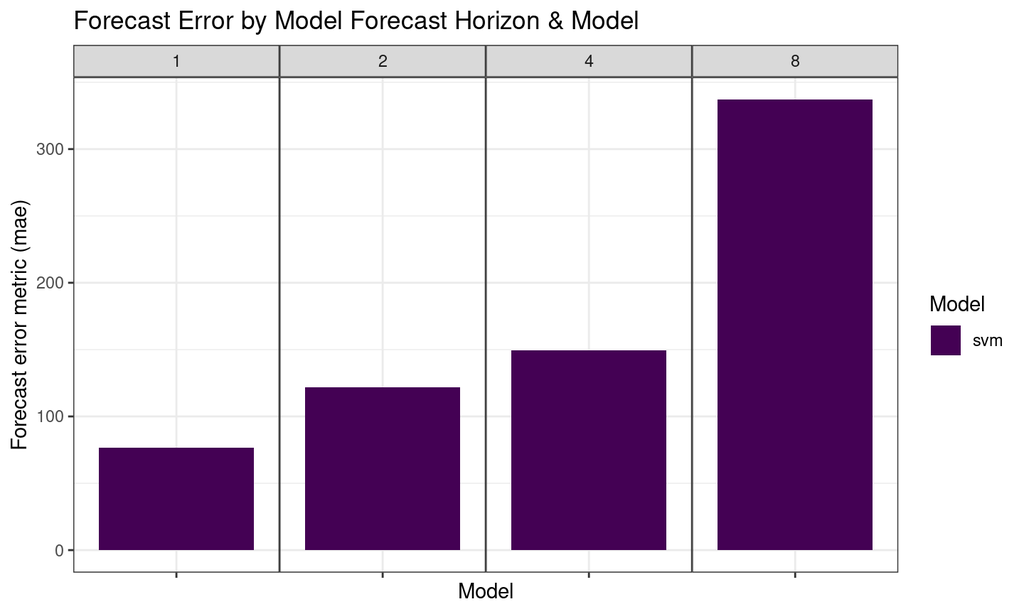

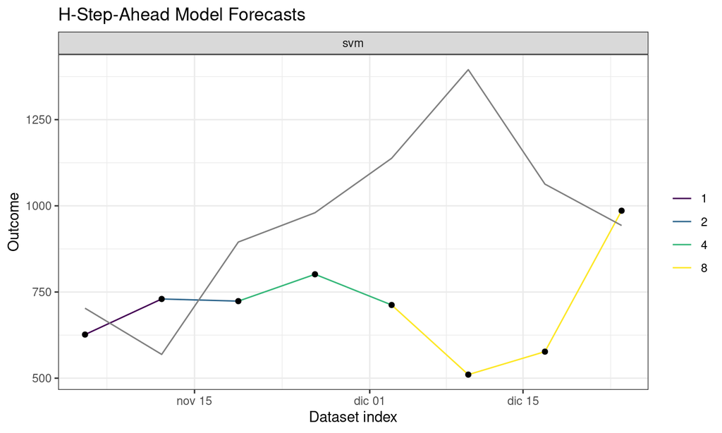

|  | model | horizon | mae | mape | mdape | smape | rmse | rmsse |
| --- | --- | --- | --- | --- | --- | --- | --- | --- |
| 1 | svm | 1 | 76.425 | 10.871 | 10.871 | 11.496 | 76.425 | 0.343 |
| 2 | svm | 2 | 160.837 | 28.267 | 28.267 | 24.766 | 160.837 | 0.722 |
| 3 | svm | 3 | 171.461 | 19.158 | 19.158 | 21.187 | 171.461 | 0.77 |
| 4 | svm | 4 | 178.566 | 18.221 | 18.221 | 20.047 | 178.566 | 0.802 |
| 5 | svm | 5 | 425.617 | 37.4 | 37.4 | 46.003 | 425.617 | 1.911 |
| 6 | svm | 6 | 884.614 | 63.413 | 63.413 | 92.854 | 884.614 | 3.973 |
| 7 | svm | 7 | 485.957 | 45.716 | 45.716 | 59.262 | 485.957 | 2.182 |
| 8 | svm | 8 | 42.859 | 4.545 | 4.545 | 4.444 | 42.859 | 0.192 |

|  | model | mae | mape | mdape | smape | rmse | rmsse |
| --- | --- | --- | --- | --- | --- | --- | --- |
| 1 | svm | 303.292 | 28.449 | 23.712 | 35.007 | 402.287 | 1.807 |

## It is better to combined the models

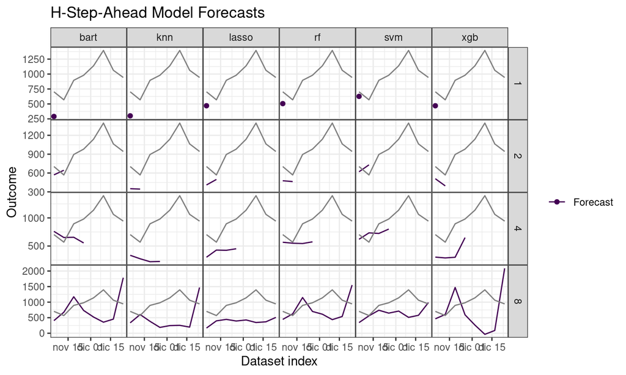

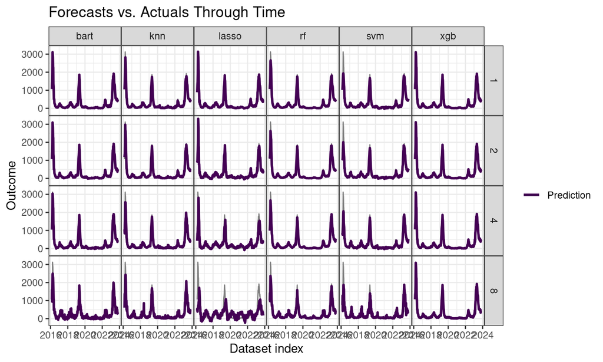

## Next Steps

## To Do

- Use time series aimed cv?
- Hyperparameters tuning.
- Feature engineering.
- Test deep learning methods (tensorflow or torch).
- Test alternative workflows.
- Adapt functions to other strategies and debug MIMO functions.
- Compare performance with classic methods.
- Include GT as predictor.

## Thank you

Questions?